# The Association Between Modern Media and Public Opinions

2015-12-01

## Summary and Purpose of Study:

The data was collected using two online surveys between the months of August and December of 2012. Political affiliation, social standing, and stance on common issues were all examined and measured quantitatively throughout two surveys that were dispersed within 4 months. Participants were asked to rate certain social and political issues presented often by asking them their opinions on a score from one to one hundred percent. The sample targeted African American/Black males over 18, African American/Black females over 18, Causasian/White males over 18, and Caucasian/White females over 18. Participants were chosen from the GfK knowledge network, which is a online panel that is supposed to represent the population of the United States. The data highlighted here is political interest, how often they keep themselves up-to-date on current events, and political affiliation. For this study, I have referenced the Outlook On Life dataset.

The purpose of this study is to examine whether modern media has an effect on the opinions of the citizens of the United States. The goals of this study are to (1) establish a relationship between Americans and media and (2) determine if American attitudes are swayed by the media.

## Variables:

Variables I have considered in my data include W1_A1 (how interested participants are in what is going on in politics and government), W1_A2 (have participants thought about the upcoming election of 2012 recently), W1_A11 (how many times participants have watched national news programs on TV or on the Internet in the past week), and W1_C1 (what do participants identify as: Democratic, Republican, Independent, or other).

```r
library(PDS)
library(dplyr)
OOL.sub <- OOL %>%
   rename(InterestPol = W1_A1, ThoughtsElections = W1_A2, WatchNews = W1_A11, PoliticalAffil = W1_C1, Welfare = W1_N1A, Congress = W1_N1I)
OOL.sub$InterestPol[OOL.sub$InterestPol == -1] <- NA
OOL.sub$InterestPol <- factor(OOL.sub$InterestPol,labels=c("Extremely","Very", "Moderately Interested", "Slightly", "Not Interested"))
table(OOL.sub$InterestPol)
```

```
            Extremely                  Very Moderately Interested
                  389                   679                   658
             Slightly        Not Interested
                  354                   198
```

```r
OOL.sub$ThoughtsElections[OOL.sub$ThoughtsElections == -1] <- NA
OOL.sub$ThoughtsElections <- factor(OOL.sub$ThoughtsElections,labels=c( "Quite a lot", "Somewhat a lot", "Somewhat a little", "Only a little", "Not at all"))
table(OOL.sub$ThoughtsElections)
```

```
      Quite a lot    Somewhat a lot Somewhat a little     Only a little
              910               599               423               236
       Not at all
              116
```

```r
OOL.sub$WatchNews[OOL.sub$WatchNews == -1] <- NA
OOL.sub$WatchNews <- factor(OOL.sub$WatchNews,labels=c ("None", "One Day", "Two Days", "Three Days", "Four Days", "Five Days", "Six Days", "Seven Days"))
table(OOL.sub$WatchNews)
```

```
      None    One Day   Two Days Three Days  Four Days  Five Days
       516        264        284        245        146        242
  Six Days Seven Days
       123        463
```

```r
OOL.sub$PoliticalAffil[OOL.sub$PoliticalAffil == -1] <- NA
OOL.sub$Welfare[OOL.sub$Welfare == 998] <- NA
OOL.sub$Congress[OOL.sub$Congress == 998] <- NA
OOL.sub$PoliticalAffil <- factor(OOL.sub$PoliticalAffil, labels=c("Republican", "Democratic", "Independent", "Something Else"))
table(OOL.sub$PoliticalAffil)
```

```
    Republican     Democratic    Independent Something Else
           331           1251            555            108
```

```r
OOL.sub <- OOL.sub %>%
   select(InterestPol, ThoughtsElections, WatchNews, PoliticalAffil, Welfare, Congress)
```

# Bar Graphs

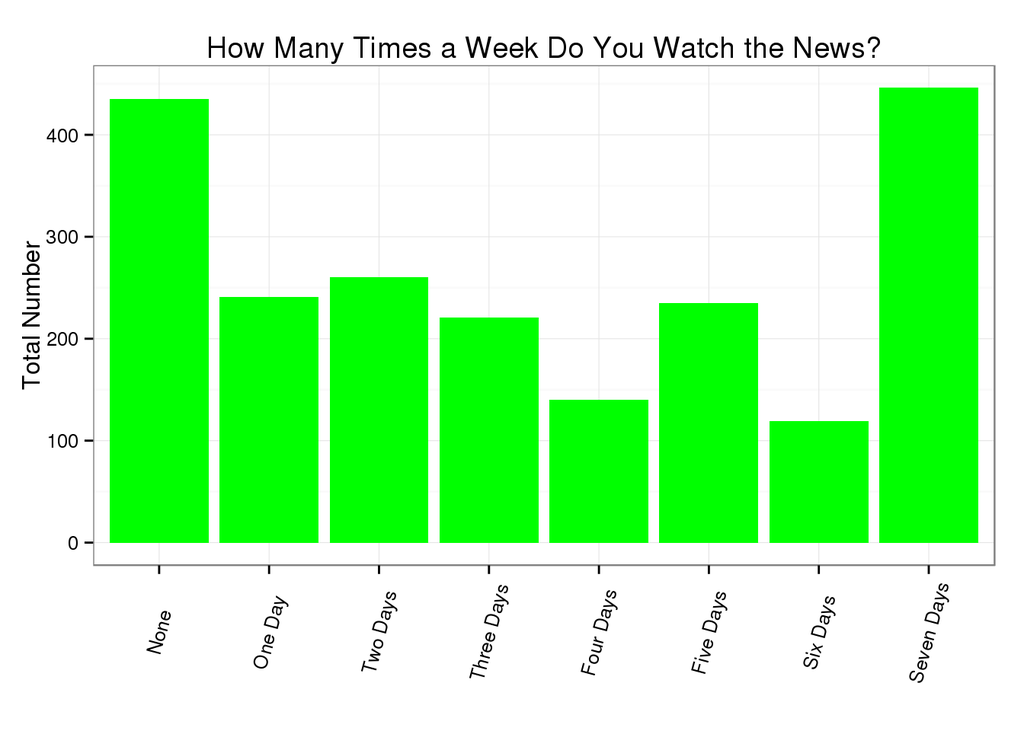

```r
library(ggplot2)
g1 <- ggplot(data = na.omit(OOL.sub), aes(WatchNews)) +
  geom_bar(fill = c("green")) +
  labs(x = "", y = "Total Number", title = "How Many Times a Week Do You Watch the News?") +
  theme_bw() +
  theme(axis.text.x  = element_text(angle = 75, vjust = 0.5))
g1
```

This is a graph of the variable “How Many Times a Week Do You Watch the News?”. This graph shows the answers of participants when asked how often they watch the news in a week. Most participants either do not watch the news at all or they watch the news seven times a week.

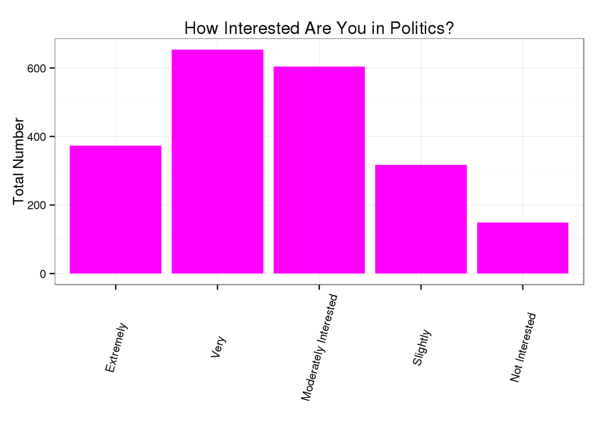

```r
g2 <- ggplot(data = na.omit(OOL.sub), aes(InterestPol)) +
  geom_bar(fill = c("magenta")) +
  labs(x = "", y = "Total Number", title = "How Interested Are You in Politics?") +
  theme_bw() +
  theme(axis.text.x  = element_text(angle = 75, vjust = 0.5))
g2
```

This is a graph of the variable “How Interested Are You In Politcs?”. This graph shows the answers of participants when asked if they were at all interested in politics and if so, how interested were they. Most participants said they were “Very Interested” or “Moderately Interested”. It is unexpected to see that most are “Very Interested” in politics when, in reference to the “How Many Times a Week Do You Watch the News?” variable, many participants do not watch the news (which could indicate that they are not up-to-date on recent events in regards to politics).

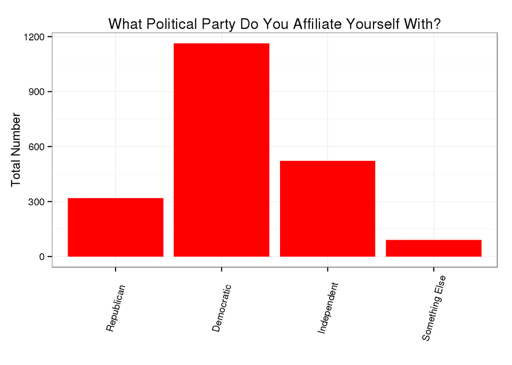

```r
g3 <- ggplot(data = na.omit(OOL.sub), aes(PoliticalAffil)) +
  geom_bar(fill = c("red")) +
  labs(x = "", y = "Total Number", title = "What Political Party Do You Affiliate Yourself With?") +
  theme_bw() +
  theme(axis.text.x  = element_text(angle = 75, vjust = 0.5))
g3
```

This is a graph of the variable “What Political Party Do You Affiliate Yourself With?”. This graph shows the answers to participants when asked what political party they are. Most participants identified as Democratic and the second most common was Independent. #Histogram

```r
summary(OOL$W1_A11)
```

```
##    Min. 1st Qu.  Median    Mean 3rd Qu.    Max.
##   -1.00    2.00    4.00    4.19    7.00    8.00
```

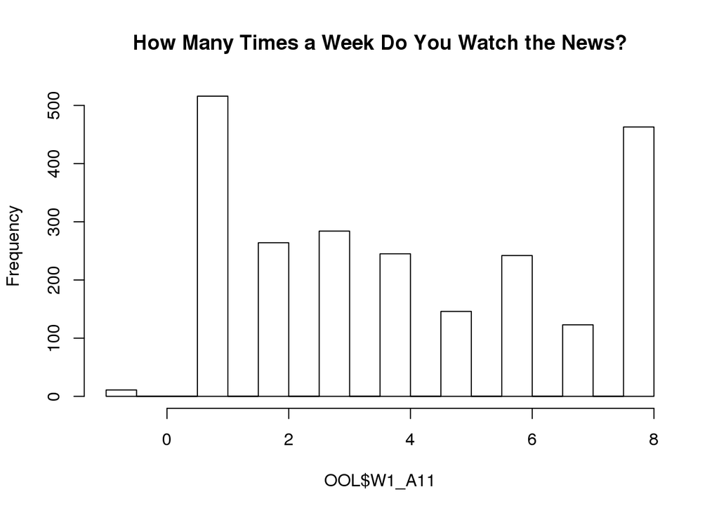

```r
hist(OOL$W1_A11, main = "How Many Times a Week Do You Watch the News?")
```

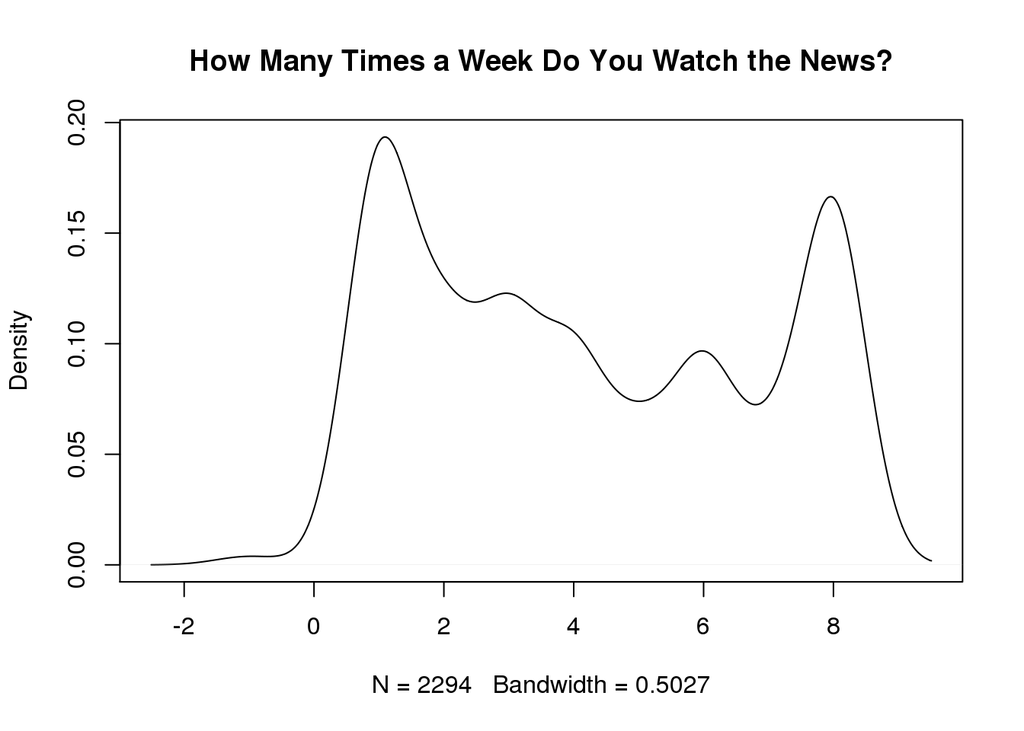

```r
plot(density(OOL$W1_A11, na.rm = TRUE), main = "How Many Times a Week Do You Watch the News?")
```

This is a histogram of the variable “How Many Times a Week Do You Watch the News?”. This graph peaks shows that the most common amount of days that participants watch the news per week are all seven days or they do not watch the news at all during the week. This is shown by the lines in the graph being significantly higher at those two points. This graph would not be considered skewed because of its two peaks at varying points.

```r
summary(OOL$W1_A11)
```

```
##    Min. 1st Qu.  Median    Mean 3rd Qu.    Max.
##   -1.00    2.00    4.00    4.19    7.00    8.00
```

```r
fivenum(OOL$W1_A11)
```

```
## [1] -1  2  4  7  8
```

```r
median(OOL$W1_A11, na.rm = TRUE)
```

```
## [1] 4
```

```r
mean(OOL$W1_A11, na.rm = TRUE)
```

```
## [1] 4.190061
```

```r
IQR(OOL$W1_A11, na.rm = TRUE)
```

```
## [1] 5
```

# Bivariate Graph

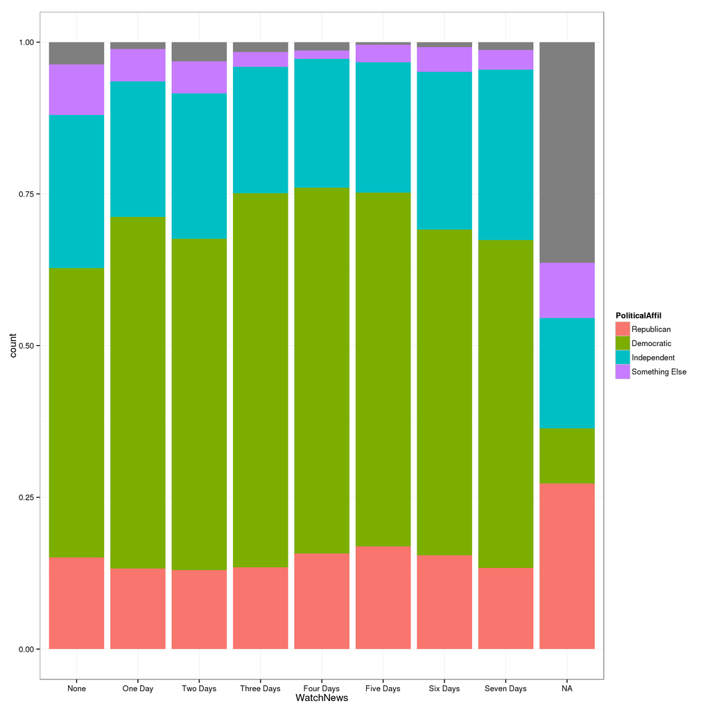

```r
g1 <- ggplot(data = OOL.sub, aes(x = WatchNews, fill = PoliticalAffil)) +
  geom_bar(position = "fill") +
  theme_bw()
g1
```

```r
library(vcd)
```

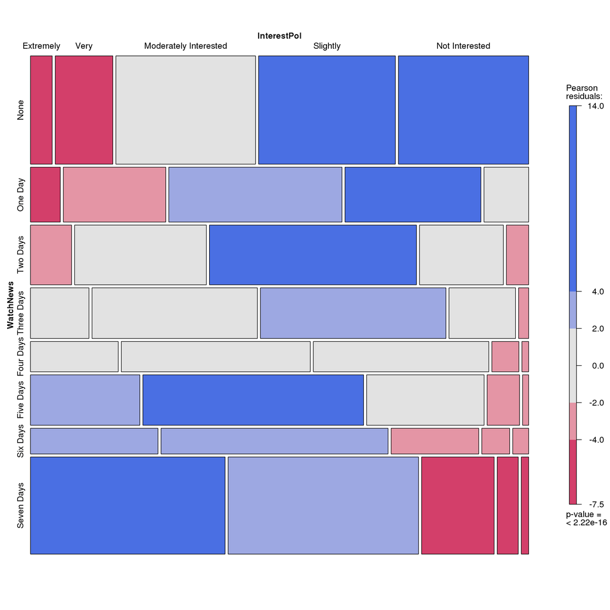

```r
mosaic(~WatchNews + InterestPol, data = OOL.sub, shade = TRUE)
```

# Hypothesis

## ANOVA

```r
tapply(OOL.sub$Welfare, OOL.sub$WatchNews, mean, na.rm = TRUE)
```

```
##       None    One Day   Two Days Three Days  Four Days  Five Days
##   45.30193   49.87059   50.04317   51.50633   51.06944   51.26360
##   Six Days Seven Days
##   50.86992   52.17249
```

```r
tapply(OOL.sub$Welfare, OOL.sub$WatchNews, sd, na.rm = TRUE)
```

```
##       None    One Day   Two Days Three Days  Four Days  Five Days
##   28.32909   25.46966   24.58372   26.00727   24.18942   25.00524
##   Six Days Seven Days
##   22.70876   23.66651
```

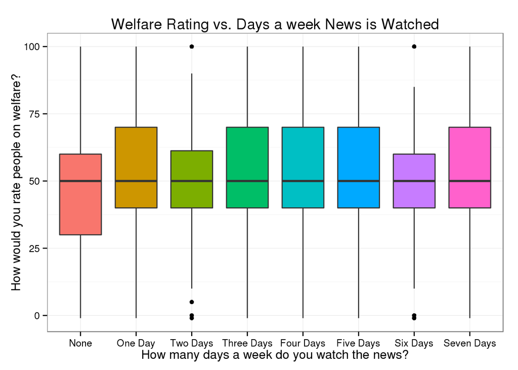

```r
library(ggplot2)
ggplot(data = na.omit(OOL.sub), aes(x = WatchNews, y = Welfare, fill= WatchNews))+
  geom_boxplot() +
  theme_bw() +
  guides(fill = FALSE) +
  labs(x = "How many days a week do you watch the news?" , y = "How would you rate people on welfare?", title= "Welfare Rating vs. Days a week News is Watched")
```

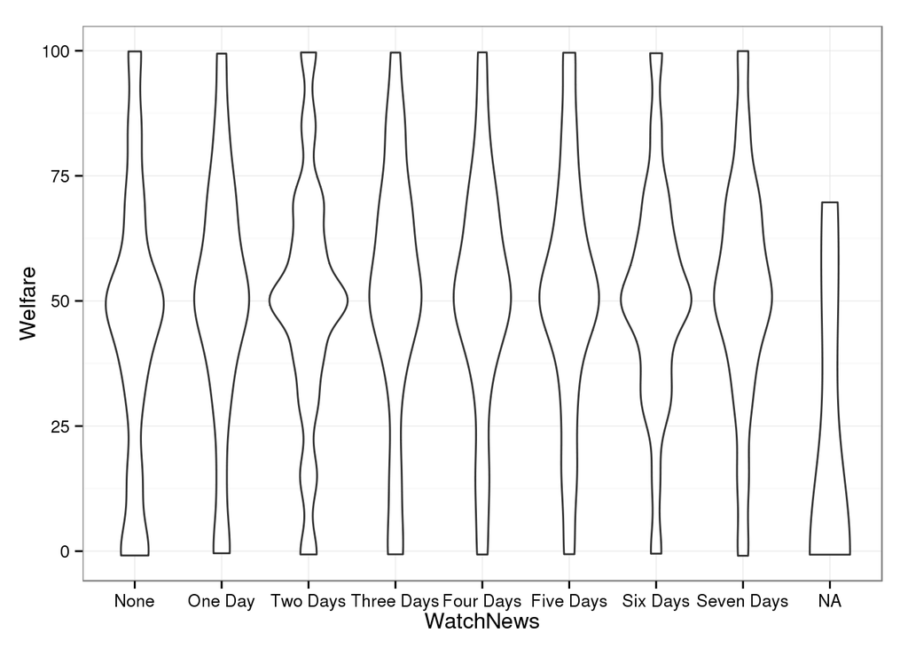

```r
ggplot(data = OOL.sub , aes(x= WatchNews, y= Welfare)) +
  geom_violin() +
  theme_bw() +
  guides(fill = FALSE) +
  labs(x = "WatchNews", y= "Welfare")
```

```r
#ANOVA Test

mod1 <- aov(Welfare ~ WatchNews, data = OOL.sub)
mod1
```

```
## Call:
##    aov(formula = Welfare ~ WatchNews, data = OOL.sub)
##
## Terms:
##                 WatchNews Residuals
## Sum of Squares    13610.2 1417152.9
## Deg. of Freedom         7      2193
##
## Residual standard error: 25.42079
## Estimated effects may be unbalanced
## 93 observations deleted due to missingness
```

```r
summary(mod1)
```

```
##               Df  Sum Sq Mean Sq F value  Pr(>F)
## WatchNews      7   13610  1944.3   3.009 0.00379 **
## Residuals   2193 1417153   646.2
## ---
## Signif. codes:  0 '***' 0.001 '**' 0.01 '*' 0.05 '.' 0.1 ' ' 1
## 93 observations deleted due to missingness
```

```r
# Post-hoc test

CIS <- TukeyHSD(mod1)
CIS
```

```
##   Tukey multiple comparisons of means
##     95% family-wise confidence level
##
## Fit: aov(formula = Welfare ~ WatchNews, data = OOL.sub)
##
## $WatchNews
##                             diff         lwr       upr     p adj
## One Day-None           4.5686610 -1.43642412 10.573746 0.2894327
## Two Days-None          4.7412383 -1.10096146 10.583438 0.2124376
## Three Days-None        6.2044019  0.05358474 12.355219 0.0462649
## Four Days-None         5.7675172 -1.58371292 13.118747 0.2515205
## Five Days-None         5.9616711 -0.17205049 12.095393 0.0638013
## Six Days-None          5.5679915 -2.24818057 13.384164 0.3759589
## Seven Days-None        6.8705619  1.79880078 11.942323 0.0010677
## Two Days-One Day       0.1725772 -6.51471371  6.859868 1.0000000
## Three Days-One Day     1.6357409 -5.32278730  8.594269 0.9966370
## Four Days-One Day      1.1988562 -6.84036935  9.238082 0.9998272
## Five Days-One Day      1.3930101 -5.55041151  8.336432 0.9987765
## Six Days-One Day       0.9993305 -7.46713919  9.465800 0.9999645
## Seven Days-One Day     2.3019008 -3.72398691  8.327789 0.9432560
## Three Days-Two Days    1.4631636 -5.35529398  8.281621 0.9981134
## Four Days-Two Days     1.0262790 -6.89201613  8.944574 0.9999329
## Five Days-Two Days     1.2204329 -5.58260715  8.023473 0.9994102
## Six Days-Two Days      0.8267532 -7.52497464  9.178481 0.9999893
## Seven Days-Two Days    2.1293236 -3.73425662  7.992904 0.9565852
## Four Days-Three Days  -0.4368847 -8.58554417  7.711775 0.9999998
## Five Days-Three Days  -0.2427308 -7.31256867  6.827107 1.0000000
## Six Days-Three Days   -0.6364104 -9.20686038  7.934040 0.9999985
## Seven Days-Three Days  0.6661600 -5.50496857  6.837289 0.9999807
## Five Days-Four Days    0.1941539 -7.94160919  8.329917 1.0000000
## Six Days-Four Days    -0.1995257 -9.66845629  9.269405 1.0000000
## Seven Days-Four Days   1.1030446 -6.26518857  8.471278 0.9998227
## Six Days-Five Days    -0.3936796 -8.95186878  8.164510 0.9999999
## Seven Days-Five Days   0.9088908 -5.24519866  7.062980 0.9998381
## Seven Days-Six Days    1.3025704 -6.52959544  9.134736 0.9996424
```

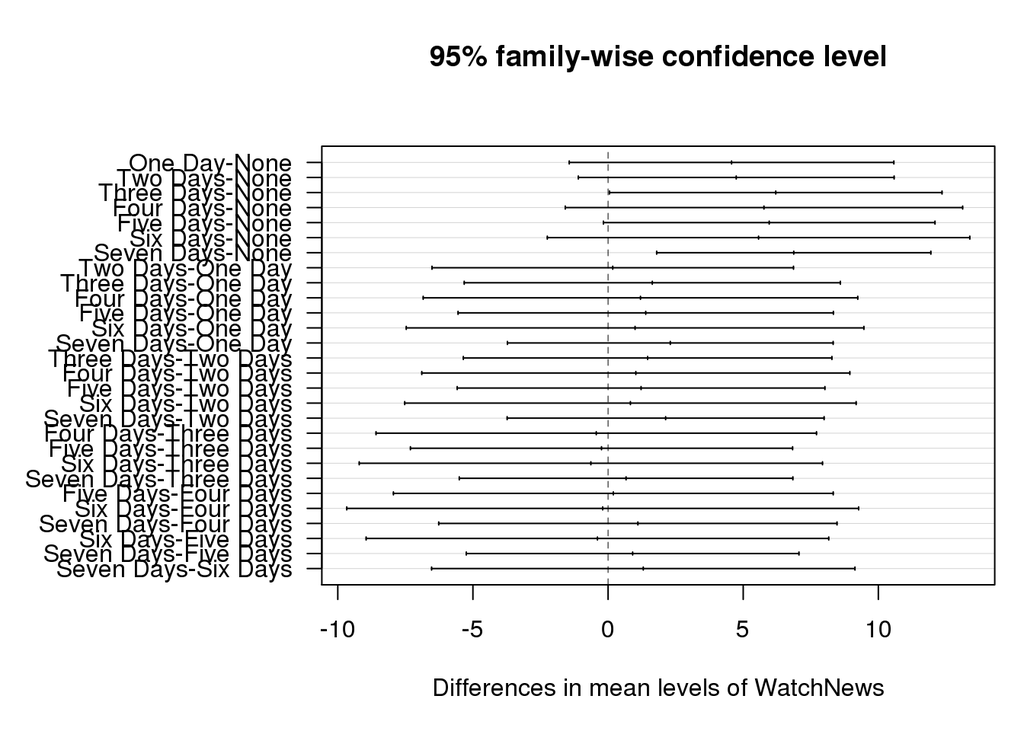

```r
opar <- par(no.readonly = TRUE)
par(mar = c(5, 11, 5, 1))
plot(CIS, las = 1)
```

```r
par(opar)
mod<- aov(Welfare~WatchNews, data=OOL.sub)
summary(mod)
```

```
##               Df  Sum Sq Mean Sq F value  Pr(>F)
## WatchNews      7   13610  1944.3   3.009 0.00379 **
## Residuals   2193 1417153   646.2
## ---
## Signif. codes:  0 '***' 0.001 '**' 0.01 '*' 0.05 '.' 0.1 ' ' 1
## 93 observations deleted due to missingness
```

```r
ci<- TukeyHSD(mod)
ci
```

```
##   Tukey multiple comparisons of means
##     95% family-wise confidence level
##
## Fit: aov(formula = Welfare ~ WatchNews, data = OOL.sub)
##
## $WatchNews
##                             diff         lwr       upr     p adj
## One Day-None           4.5686610 -1.43642412 10.573746 0.2894327
## Two Days-None          4.7412383 -1.10096146 10.583438 0.2124376
## Three Days-None        6.2044019  0.05358474 12.355219 0.0462649
## Four Days-None         5.7675172 -1.58371292 13.118747 0.2515205
## Five Days-None         5.9616711 -0.17205049 12.095393 0.0638013
## Six Days-None          5.5679915 -2.24818057 13.384164 0.3759589
## Seven Days-None        6.8705619  1.79880078 11.942323 0.0010677
## Two Days-One Day       0.1725772 -6.51471371  6.859868 1.0000000
## Three Days-One Day     1.6357409 -5.32278730  8.594269 0.9966370
## Four Days-One Day      1.1988562 -6.84036935  9.238082 0.9998272
## Five Days-One Day      1.3930101 -5.55041151  8.336432 0.9987765
## Six Days-One Day       0.9993305 -7.46713919  9.465800 0.9999645
## Seven Days-One Day     2.3019008 -3.72398691  8.327789 0.9432560
## Three Days-Two Days    1.4631636 -5.35529398  8.281621 0.9981134
## Four Days-Two Days     1.0262790 -6.89201613  8.944574 0.9999329
## Five Days-Two Days     1.2204329 -5.58260715  8.023473 0.9994102
## Six Days-Two Days      0.8267532 -7.52497464  9.178481 0.9999893
## Seven Days-Two Days    2.1293236 -3.73425662  7.992904 0.9565852
## Four Days-Three Days  -0.4368847 -8.58554417  7.711775 0.9999998
## Five Days-Three Days  -0.2427308 -7.31256867  6.827107 1.0000000
## Six Days-Three Days   -0.6364104 -9.20686038  7.934040 0.9999985
## Seven Days-Three Days  0.6661600 -5.50496857  6.837289 0.9999807
## Five Days-Four Days    0.1941539 -7.94160919  8.329917 1.0000000
## Six Days-Four Days    -0.1995257 -9.66845629  9.269405 1.0000000
## Seven Days-Four Days   1.1030446 -6.26518857  8.471278 0.9998227
## Six Days-Five Days    -0.3936796 -8.95186878  8.164510 0.9999999
## Seven Days-Five Days   0.9088908 -5.24519866  7.062980 0.9998381
## Seven Days-Six Days    1.3025704 -6.52959544  9.134736 0.9996424
```

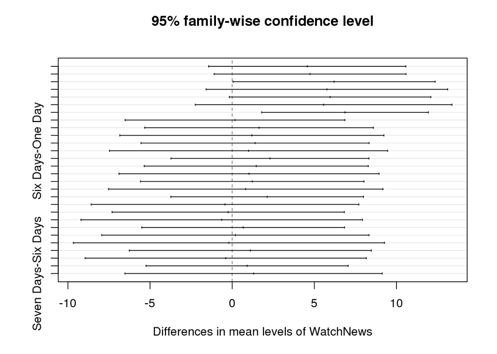

```r
plot(ci)
```

## Chi-Squared

Hypothesis: The Interest in Politics and Political affiliation variables are independent. The alternative would be they are dependent on one another.

```r
chi.name <- chisq.test(OOL.sub$InterestPol, OOL.sub$PoliticalAffil)
chi.name$obs
```

```
##                        OOL.sub$PoliticalAffil
## OOL.sub$InterestPol     Republican Democratic Independent Something Else
##   Extremely                     53        221          92             19
##   Very                         112        365         171             22
##   Moderately Interested         94        379         146             25
##   Slightly                      51        186          88             19
##   Not Interested                20         92          54             23
```

```r
tbl= table(OOL.sub$InterestPol, OOL.sub$PoliticalAffil)
tbl
```

```
##
##                         Republican Democratic Independent Something Else
##   Extremely                     53        221          92             19
##   Very                         112        365         171             22
##   Moderately Interested         94        379         146             25
##   Slightly                      51        186          88             19
##   Not Interested                20         92          54             23
```

```r
chisq.test(tbl)
```

```
##
##  Pearson's Chi-squared test
##
## data:  tbl
## X-squared = 36.113, df = 12, p-value = 0.0003108
```

```r
chisq.test(tbl)$exp
```

```
##
##                         Republican Democratic Independent Something Else
##   Extremely               56.92204   214.4064    95.04256      18.629032
##   Very                    99.05914   373.1228   165.39875      32.419355
##   Moderately Interested   95.21505   358.6434   158.98029      31.161290
##   Slightly                50.86022   191.5735    84.92115      16.645161
##   Not Interested          27.94355   105.2540    46.65726       9.145161
```

```r
p1<- chisq.test(tbl[,c(1,2)])
p2<- chisq.test(tbl[,c(1,3)])
p3<- chisq.test(tbl[,c(1,4)])
p4 <-chisq.test(tbl[,c(2,3)])
p5 <-chisq.test(tbl[,c(3,4)])$p.value
p6 <-chisq.test(tbl[,c(2,4)])
```

## Correlation Coefficient

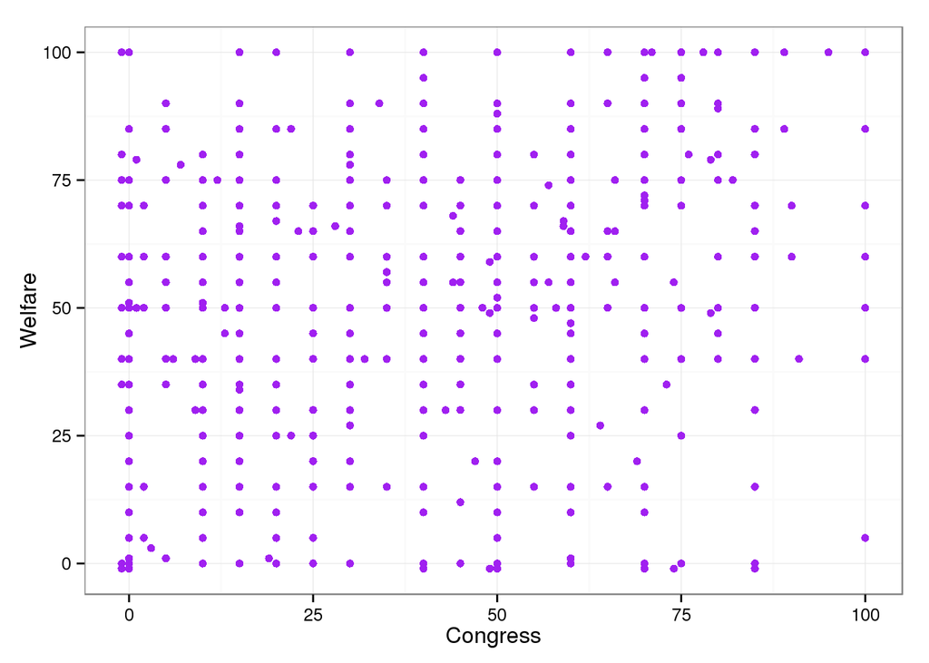

```r
library(ggplot2)
 ggplot(data = OOL.sub, aes(x = Congress, y = Welfare)) +
   geom_point(color = "purple") +
   theme_bw()
```

This correlation coefficient measures how participants would rate Congress from 1-100 and it’s correlation to how participants rate people on welfare from 1-100.

```r
cor(OOL.sub$Congress, OOL.sub$Welfare)
```

```
## [1] NA
```

```r
cor.test(OOL.sub$Congress, OOL.sub$Welfare)
```

```
##
##  Pearson's product-moment correlation
##
## data:  OOL.sub$Congress and OOL.sub$Welfare
## t = 15.589, df = 2163, p-value < 2.2e-16
## alternative hypothesis: true correlation is not equal to 0
## 95 percent confidence interval:
##  0.2794215 0.3551798
## sample estimates:
##       cor
## 0.3178078
```

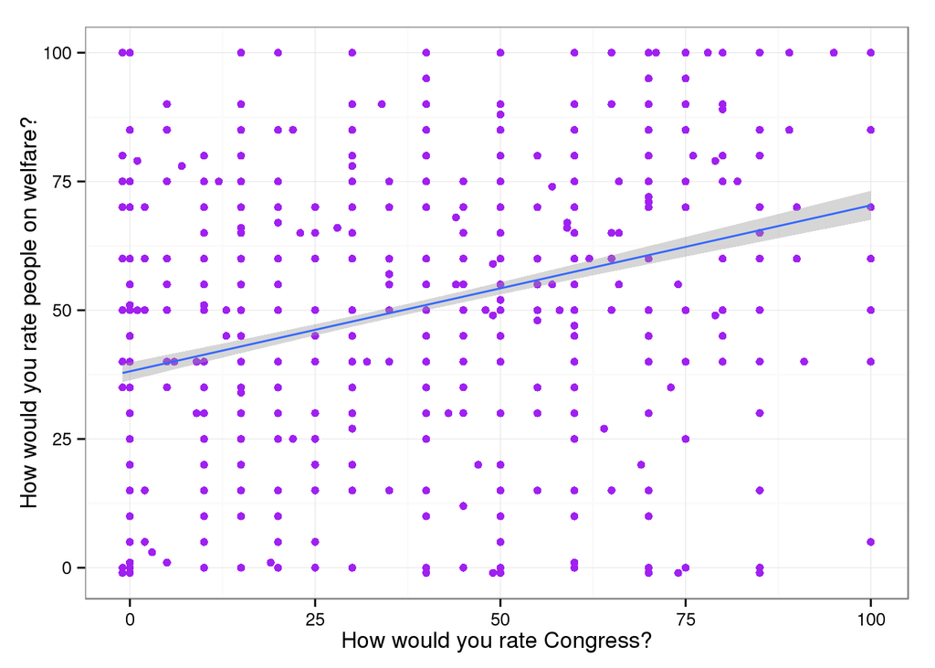

```r
ggplot(data = OOL.sub, aes(x = Congress, y = Welfare)) +
geom_point(color = "purple") +
theme_bw() +
labs(x = "How would you rate Congress?", y = "How would you rate people on welfare?") +
stat_smooth(method = lm)
```

The correlation of the data is estimated to be 0.3178078. There is no one set direction that the data is graphed. Most of the data is scattered all around the graph. Therefore, there is not a very strong correlation coefficient. There is a slight upward slope in the correlation gap. There are a few outliers, such as a participant rating Congress as 100 and people on welfare between 1-25.

## Regression Assignment

```r
mod <- lm(Congress ~ Welfare, data = OOL.sub)
summary(mod)
```

```
##
## Call:
## lm(formula = Congress ~ Welfare, data = OOL.sub)
##
## Residuals:
##     Min      1Q  Median      3Q     Max
## -51.947 -20.280   1.587  15.688  78.821
##
## Coefficients:
##             Estimate Std. Error t value Pr(>|t|)
## (Intercept)  19.6122     1.1178   17.55   <2e-16 ***
## Welfare       0.3134     0.0201   15.59   <2e-16 ***
## ---
## Signif. codes:  0 '***' 0.001 '**' 0.01 '*' 0.05 '.' 0.1 ' ' 1
##
## Residual standard error: 23.79 on 2163 degrees of freedom
##   (129 observations deleted due to missingness)
## Multiple R-squared:  0.101,  Adjusted R-squared:  0.1006
## F-statistic:   243 on 1 and 2163 DF,  p-value: < 2.2e-16
```

```r
predict(mod, newdata = data.frame(Welfare = 60))
```

```
##        1
## 38.41324
```

```r
PV <- predict(mod, newdata = data.frame(Welfare = 60))
PV
```

```
##        1
## 38.41324
```